# Aula 3 - Econometria de Séries Temporais

João Ricardo F. de Lima

03 de Agosto de 2022.

# 1 Análise da Sazonalidade

**Variações sazonais** são movimentos cíclicos que se completam no período de um ano e se reproduzem nos outros anos com certa regularidade. Em outras palavras, *sazonalidade* significa dizer que em determinados meses os valores estão sistematicamente acima ou abaixo de um valor médio da série.

Se isola o componente sazonal da série temporal por dois motivos:

1. remover o componente sazonal para estudar os outros componentes; ou
2. identificar o componente sazonal que expressam a intensidade da sazonalidade a cada período.

A interdependência temporal na série, então, ocorre de duas maneiras:

1. correlação entre as observações para meses sucessivos em dado ano, isto é, $Y_t$ relacionado com $Y_{t-1}, Y_{t-2}, Y_{t-3}$, etc;
2. correlação entre as observações para o mesmo mês em anos sucessivos, ou seja, $Y_t$ relacionado com $Y_{t-s}, Y_{t-2s}, Y_{t-3s}$ em que “s” é o período sazonal considerado.

Considere uma série temporal de preços da melancia. Em janeiro de 2014, por exemplo, é relacionado com o preço de dezembro de 2013, de novembro de 2013, de outubro de 2013, além de janeiro de 2013, janeiro de 2012, janeiro de 2011, etc.. O mesmo ocorreria com qualquer outra série histórica macroeconômica; Séries sazonais apresentam correlações altas nos *lags sazonais*, que são os lags múltiplos de “s”.

# 2 Sazonalidade Determinística

A *sazonalidade* pode ser de natureza **determinística** ou **estocástica**. A sazonalidade determinística é aquela que tem um padrão previsível a partir de meses anteriores e normalmente está relacionada com a influência de fenomenos climáticos ou datas específicas que se repetem ano a ano.

Pode ser analisada por meio de regressão ou médias móveis.

## 2.1 Sazonalidade - Regressão

A sazonalidade determinística pode ser analisada pelo **método de regressão** com o uso de *dummies*. Considere:

$$Y_t=T_t+S_t+\epsilon_t$$

em que a tendência é dada por por $T_t=\sum_{j=0}^{k}\beta_jt^j$;

Se a sazonalidade é determinística, o padrão sazonal não varia a cada ano e pode ser representado por 12 dummies sazonais $S_t=\sum_{j=1}^{12}\alpha_jd_{jt}$

Cada série de dummy sazonal da variável “y” pode ser facilmente gerada no R pelo comando `dseas1 <- seasonaldummy(y)`. Se a restrição $\sum_{j=i}^{12}d_j=0$ for usada, $\alpha_j$ representa o efeito sazonal do período “s” comparado com uma linha de tendencia média.

Estima-se o seguinte modelo:

$$Y_t=\sum_{j=0}^{k}\beta_jt^j+\sum_{j=1}^{11}\alpha_jD_{jt}+\epsilon_t$$

os coeficientes $\alpha_1, \alpha_2, \dots, \alpha_12$ são as constantes sazonais.

Dado que $\sum_{j=i}^{12}d_j=0$, $\alpha_{12}=-(\alpha_1+\alpha_2+ \dots+ \alpha_{11})$

## 2.2 Exemplo Sazonalidade Determinística por regressão no R

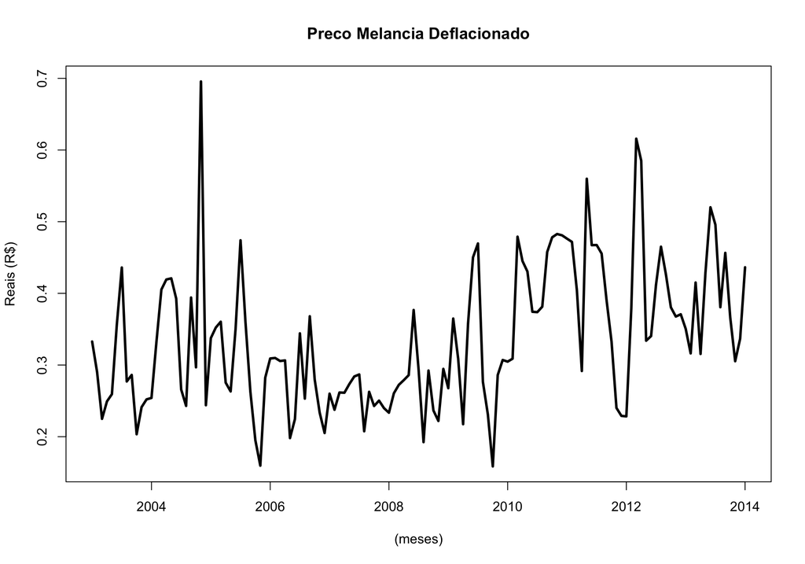

```r
#Direcionando o R para o Diretorio a ser trabalhado
setwd('/Users/jricardofl/Dropbox/tempecon/facape/econometria2')

#Limpa o Ambiente Global
rm(list=ls())

#Inicio do Script
#Pacotes a serem utilizados
library(foreign)
library(mFilter)
library(forecast)
library(dplyr)
library(tsutils)
library(ggplot2)

#Entrando com os dados
melancia <- read.dta("melancia1.dta")
melancia <- melancia[,-c(1:6)] #deixar apenas a ultima coluna

#Setando como série temporal
melancia <- ts(melancia, start=c(2003,01), freq=12)

#Grafico da evolucao do preco da Melancia
plot(melancia, main='Preco Melancia Deflacionado',
     xlab='(meses)', ylab='Reais (R$)', lwd=3)
```

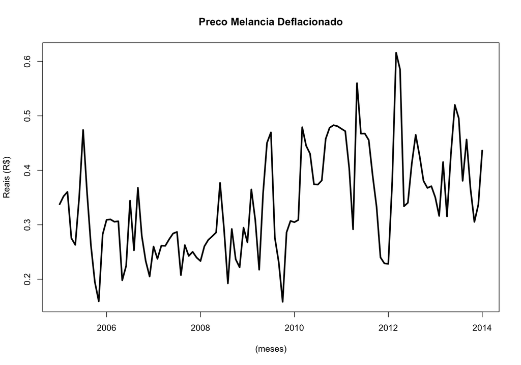

```r
#Usando apenas uma parte dos dados
melancia1 <- window(melancia, start=c(2005,1))

#Grafico da evolucao do preco da melancia
plot(melancia1, main='Preco Melancia Deflacionado',
     xlab='(meses)', ylab='Reais (R$)', lwd=3)
```

```r
#Geracao da variavel tendencia
trend <- 1:length(melancia1)

#Geracao das variaveis Dummy Sazonais
dseas1 <- seasonaldummy(melancia1)
for(i in c(12, 24, 36, 48, 60, 72, 84, 96, 108)) {
  dseas1[i,] <- -1
}

regressao1 <- lm(melancia1 ~ trend + dseas1)
summary(regressao1)
```

```
#
# Call:
# lm(formula = melancia1 ~ trend + dseas1)
#
# Residuals:
#       Min        1Q    Median        3Q       Max
# -0.141019 -0.047832 -0.009237  0.041531  0.195748
#
# Coefficients:
#               Estimate Std. Error t value Pr(>|t|)
# (Intercept)  0.2482437  0.0152817  16.245  < 2e-16 ***
# trend        0.0016322  0.0002414   6.761 1.07e-09 ***
# dseas1Jan   -0.0176034  0.0240111  -0.733   0.4653
# dseas1Feb    0.0035569  0.0252129   0.141   0.8881
# dseas1Mar    0.0488330  0.0252025   1.938   0.0556 .
# dseas1Apr   -0.0023438  0.0251944  -0.093   0.9261
# dseas1May    0.0133273  0.0251886   0.529   0.5980
# dseas1Jun    0.0400574  0.0251851   1.591   0.1150
# dseas1Jul    0.0639161  0.0251840   2.538   0.0128 *
# dseas1Aug   -0.0094207  0.0251851  -0.374   0.7092
# dseas1Sep    0.0083844  0.0251886   0.333   0.7400
# dseas1Oct   -0.0461997  0.0251944  -1.834   0.0698 .
# dseas1Nov   -0.0615060  0.0252025  -2.440   0.0165 *
# ---
# Signif. codes:  0 '***' 0.001 '**' 0.01 '*' 0.05 '.' 0.1 ' ' 1
#
# Residual standard error: 0.07894 on 96 degrees of freedom
# Multiple R-squared:  0.4065,  Adjusted R-squared:  0.3323
# F-statistic: 5.479 on 12 and 96 DF,  p-value: 4.96e-07
```

### 2.2.1 Gráfico dos coeficientes da regressão

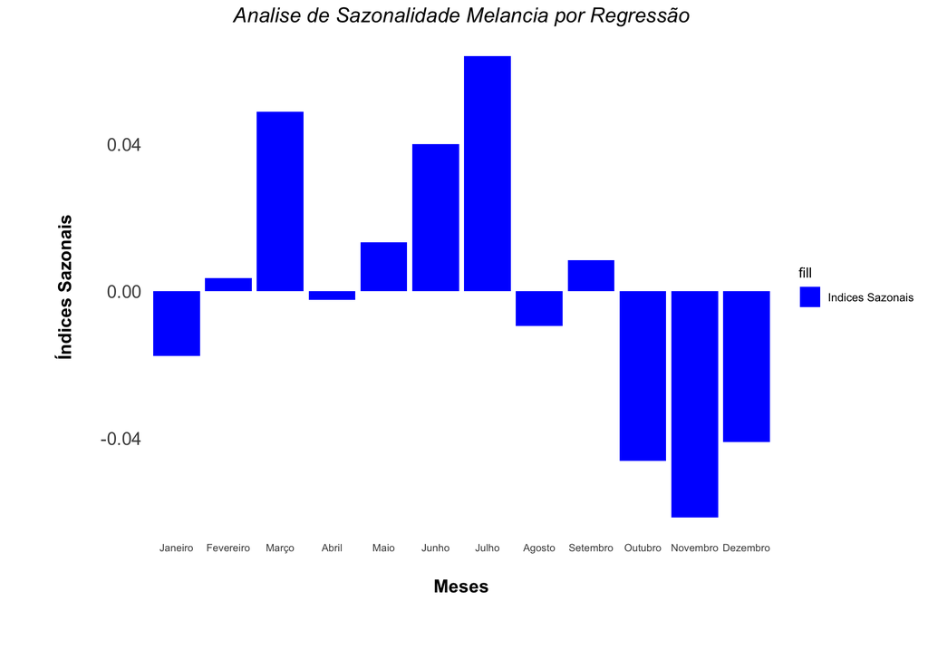

```r
# Organização dos Coeficientes da Regressão

coeffs <- coefficients(regressao1) #salva os coeficientes do modelo

#Calculo do efeito sazonal para dezembro como sendo o
#negativo do somatorio dos outros meses

dezembro <- as.data.frame(-(coeffs[3]+coeffs[4]+coeffs[5]+coeffs[6]+coeffs[7]+
                              coeffs[8]+coeffs[9]+coeffs[10]+coeffs[11]
                            +coeffs[12]+coeffs[13]))
colnames(dezembro)[1] <- "coeffs"
rownames(dezembro)[1] <- "Dezembro"

#salva os coeficientes estimados em um data frame
coeffs <- as.data.frame(coeffs)
rownames(coeffs) <- c("intercepto", "tendencia", "Janeiro", "Fevereiro", "Março",
                      "Abril", "Maio", "Junho", "Julho", "Agosto", "Setembro",
                      "Outubro", "Novembro")

# adiciona uma linha no primeiro data frame, juntando dezembro
# com os demais meses
indices_sazonais <- bind_rows(coeffs, dezembro)

#retira as duas primeiras linhas
indices_sazonais <- indices_sazonais %>% slice(-(1:2))

#cria uma variável "meses"
indices_sazonais$meses <- c("Janeiro", "Fevereiro", "Março",
                      "Abril", "Maio", "Junho", "Julho", "Agosto", "Setembro",
                      "Outubro", "Novembro", "Dezembro")

#Transforma a variável em um factor para fazer o gráfico sem mudar
#a ordem do eixo do x
indices_sazonais$meses <- factor(indices_sazonais$meses, levels = indices_sazonais$meses)

#Gráfico

mycolor1 <- "blue" #escolhe a cor do gráfico

ggplot(data=indices_sazonais, aes(x=meses, y=coeffs, fill="Indices Sazonais"))+
  geom_col()+
    scale_fill_manual(values=mycolor1)+
    labs(y= "Índices Sazonais", x= "Meses", title='Analise de Sazonalidade Melancia por Regressão',
       caption = "")+
    theme_minimal()+ #Definindo tema
    theme(axis.text.x=element_text(angle=0, hjust=0.5, size=8, margin = margin(b=20)),
        axis.text.y=element_text(hjust=1, size=14, margin = margin(l=20)),
        axis.title.x = element_text(size=14, face = "bold", margin = margin(b=20)),
        axis.title.y = element_text(size=14, face = "bold", margin = margin(l=40)),
        plot.title = element_text(hjust = 0.5, size=16, face="italic"),
        panel.grid.major = element_blank(),
        panel.grid.minor = element_blank(),
        plot.caption = element_text(hjust = 0, size=12)) # Definindo posição da legenda
```

### 2.2.2 Gráfico da Série sem Sazonalidade e sem Tendência pelo método da regressão

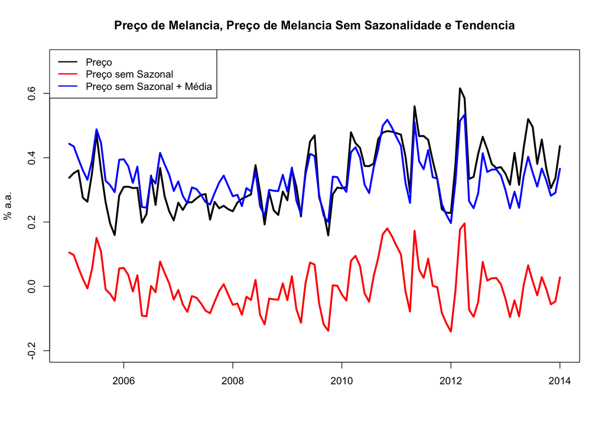

```r
#Série retirada a sazonalidade e tendencia
melancia.saz <- ts(residuals(regressao1)+ mean(fitted(regressao1)), start=c(2005,1), freq=12)
melancia1.saz <- ts(residuals(regressao1), start=c(2005,01), freq=12)

#Gráficos
plot(melancia1, main="Preço de Melancia, Preço de Melancia Sem Sazonalidade e Tendencia",
     xlab='', ylab='% a.a.', lwd=3, ylim=c(-0.2, 0.7))
lines(melancia1.saz, col='red', lwd=3)
lines(melancia.saz, col='blue', lwd=3)
legend('topleft', col=c('black','red', 'blue'), lty=c(1,1), lwd=c(2,2),
       legend=c('Preço', 'Preço sem Sazonal', 'Preço sem Sazonal + Média'))
```

## 2.3 Sazonalidade - método das Médias Móveis

Os resultados mais importantes que se obtém do ajustamento por média móvel são:

1. fatores sazonais que caracterizam o padrão de variação sazonal da série;
2. série dessazonalizada;

Uma série temporal pode ser decomposta nos seus componentes segundo o modelo aditivo ou multiplicativo. O modelo aditivo e a representação das variações sazonais e aleatórias são:

$$Y=T+S+I, \qquad logo, \quad Y-T=S+I$$

Para o modelo multiplicativo,

$$Y=TSI, \qquad logo, \quad \frac{Y}{T}=SI$$

### 2.3.1 Sazonalidade - Médias Móveis no R

No R será usado o comando `cmav` do pacote `tsutils` para se encontrar a série suavizada pelo método de médias móveis e, depois, para retirar a sazonalidade da série.

É possível fazer o gráfico da série suavizada e da série dessazonalizada.

Com o uso do comando `seasplot` do pacote `tsutils`, é gerado um gráfico dos fatores sazonais.

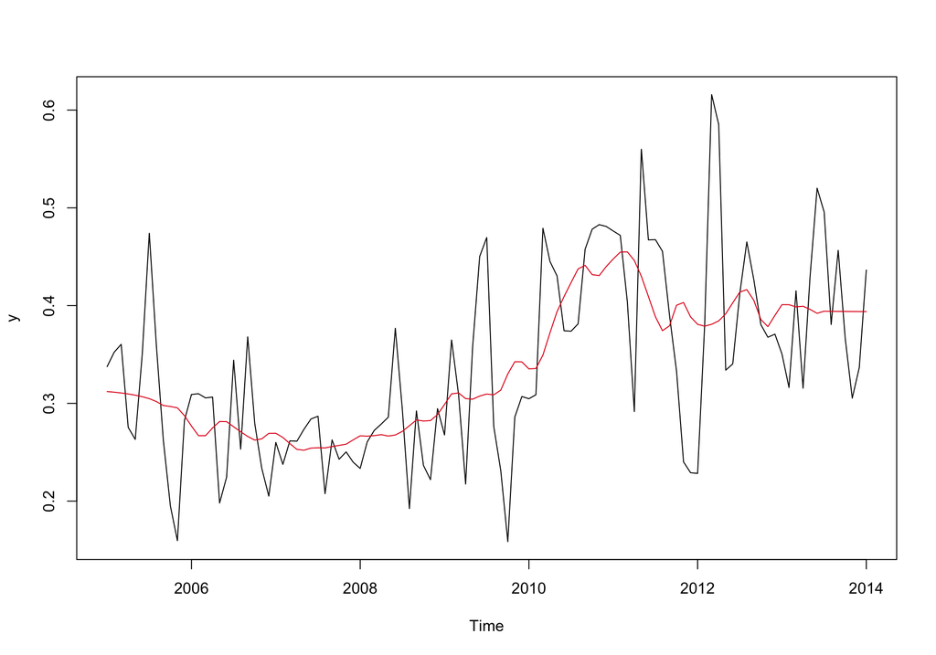

```
#            Jan       Feb       Mar       Apr       May       Jun       Jul
# 2005 0.3120783 0.3114345 0.3106298 0.3096238 0.3083665 0.3067947 0.3048301
# 2006 0.2768105 0.2669538 0.2669201 0.2748531 0.2814539 0.2813129 0.2760457
# 2007 0.2694075 0.2651191 0.2588306 0.2529137 0.2520874 0.2542359 0.2545753
# 2008 0.2667763 0.2664186 0.2670210 0.2679946 0.2665503 0.2676484 0.2713561
# 2009 0.2988717 0.3097123 0.3106650 0.3048658 0.3042858 0.3074746 0.3095358
# 2010 0.3352756 0.3356566 0.3494699 0.3722280 0.3937432 0.4091880 0.4235851
# 2011 0.4477246 0.4547168 0.4549987 0.4461425 0.4299817 0.4093724 0.3885435
# 2012 0.3808689 0.3789688 0.3808670 0.3843451 0.3916377 0.4028578 0.4138521
# 2013 0.4009504 0.4009120 0.3986532 0.3993215 0.3961342 0.3921141 0.3942700
# 2014 0.3938655
#            Aug       Sep       Oct       Nov       Dec
# 2005 0.3018775 0.2978254 0.2968311 0.2954109 0.2874594
# 2006 0.2709886 0.2661470 0.2624368 0.2636980 0.2693184
# 2007 0.2544261 0.2558288 0.2570039 0.2582529 0.2626364
# 2008 0.2771267 0.2829884 0.2819464 0.2823973 0.2884695
# 2009 0.3087461 0.3135086 0.3300909 0.3425893 0.3424350
# 2010 0.4375254 0.4411960 0.4316816 0.4306829 0.4399499
# 2011 0.3743370 0.3792815 0.4003357 0.4031543 0.3884532
# 2012 0.4163322 0.4053614 0.3857550 0.3785035 0.3899833
# 2013 0.3941601 0.3940725 0.3940024 0.3939463 0.3939014
# 2014
```

```r
#Calculo da sazonalidade por media movel centralizada.
cmav(melancia1, outplot=T)
```

```r
#Salvando os valores da sazonalidade em um objeto
melancia.ma <- cmav(melancia1)
```

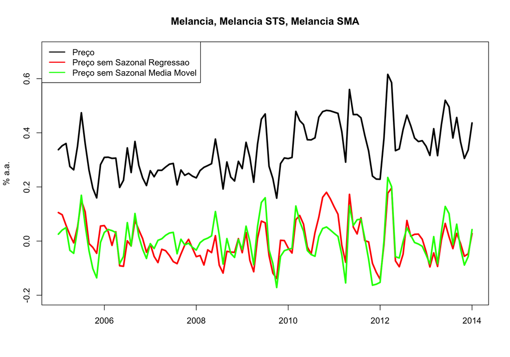

```r
#Série sem sazonalidade por medias moveis
melssazma <- melancia1 - melancia.ma

#Gráficos
plot(melancia1, main='Melancia, Melancia STS, Melancia SMA',
     xlab='', ylab='% a.a.', lwd=3, ylim=c(-0.2, 0.7))
lines(melancia1.saz, col='red', lwd=3)
lines(melssazma, col='green', lwd=3)
legend('topleft', col=c('black','red', 'green'), lty=c(1,1), lwd=c(2,2),
       legend=c('Preço', 'Preço sem Sazonal Regressao', 'Preço sem Sazonal Media Movel'))
```

## 2.4 Analise da Sazonalidade com o seasplot

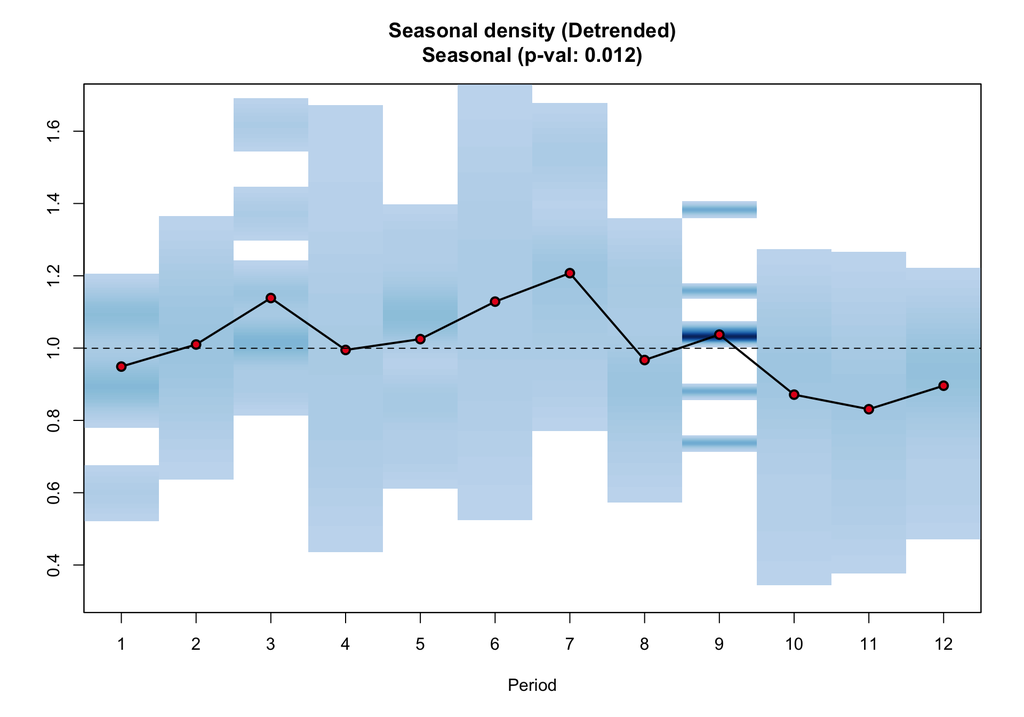

```
# Results of statistical testing
# Evidence of trend: TRUE  (pval: 0)
# Evidence of seasonality: TRUE  (pval: 0.012)
```

```r
seasplot(melancia1, outplot = 5)
```